# **Pneumonia Detection from Chest X-Rays**

## Improving a ResNet Baseline with EfficientNet, Smarter Preprocessing, and Grad-CAM Interpretability

## **Table of Contents**

1. Objective
2. Dataset Overview
3. Environment Setup & Data Download
4. Data Loading & Preprocessing
5. Sample Images from the Training Set
6. Class Distribution
7. Model Architecture
8. Training Configuration
9. Learning Curves
10. Evaluation on the Test Set
11. Interpretability with Grad-CAM++
12. Conclusion

## **Objective**

This project builds on the Kaggle notebook ["Pneumonia Detection with ResNet & PyTorch" by Denver Magtibay](https://www.kaggle.com/code/denvermagtibay/pneumonia-detection-with-resnet-pytorch) and introduces several targeted improvements to push classification performance further.  
The changes span three areas. First, the preprocessing pipeline was refined: unnecessary black borders were removed via center cropping, and grayscale X-rays were converted to three-channel RGB to ensure full compatibility with ImageNet-pretrained weights. Second, the validation split was enlarged to produce more reliable and stable evaluation metrics. Third, the backbone was upgraded from ResNet-18 to EfficientNet-B0, a more parameter-efficient architecture that has demonstrated strong performance on medical imaging tasks.  
Beyond classification, Grad-CAM (Gradient-weighted Class Activation Mapping) was applied as a post-hoc interpretability technique, producing heatmaps that highlight the regions of each X-ray that most influenced the model's prediction — an important step toward building trust in AI-assisted diagnostics.

## **Dataset Overview**

The dataset is the publicly available [Chest X-Ray Images (Pneumonia)](https://www.kaggle.com/datasets/paultimothymooney/chest-xray-pneumonia) dataset from Kaggle, consisting of pediatric chest radiographs collected at Guangzhou Women and Children's Medical Center. Each image is labeled as either **NORMAL** or **PNEUMONIA**.  
The dataset comes pre-split into training, validation, and test folders. However, the original validation set contains only 16 images — far too few for meaningful model evaluation. In this project, the validation split was expanded by redistributing samples from the training set, resulting in a more representative evaluation subset.  
The dataset is notably imbalanced: pneumonia cases significantly outnumber normal ones. Rather than resampling the data, this imbalance was addressed algorithmically by computing per-class weights and incorporating them directly into the loss function during training, encouraging the model to treat both classes with equal importance.

## **Environment Setup & Data Download**

The dataset is downloaded directly from Kaggle using the Kaggle API. To run this notebook, upload your `kaggle.json` credentials file when prompted.

```python
!pip install kaggle
from google.colab import files
import os

# Upload kaggle.json only once
files.upload()

!mkdir -p ~/.kaggle
!cp kaggle.json ~/.kaggle/
!chmod 600 ~/.kaggle/kaggle.json

# Download dataset directly from Kaggle
!kaggle datasets download -d paultimothymooney/chest-xray-pneumonia

# Unzip
!unzip -q chest-xray-pneumonia.zip
# Now dataset is in folder: chest_xray/train, test, val
!ls chest_xray
```

Upload widget is only available when the cell has been executed in the current browser session. Please rerun this cell to enable.

```
Saving kaggle.json to kaggle.json
Dataset URL: https://www.kaggle.com/datasets/paultimothymooney/chest-xray-pneumonia
License(s): other
Downloading chest-xray-pneumonia.zip to /content
 99% 2.27G/2.29G [00:30<00:00, 46.1MB/s]
100% 2.29G/2.29G [00:30<00:00, 79.9MB/s]
chest_xray  __MACOSX  test  train  val
```

## **Data Loading & Preprocessing**

All images were converted from grayscale to three-channel RGB before applying any transforms, ensuring full compatibility with ImageNet-pretrained weights. Pixel values were then normalized using ImageNet mean and standard deviation statistics.  
To remove the irrelevant dark borders common in chest X-rays and focus the model on the central anatomical region, a two-step spatial transform was applied: images were first resized to 256×256 pixels, then center-cropped to 224×224 pixels.  
During training, mild data augmentation was applied — including random horizontal flips, small rotations, and slight translations — to reduce overfitting and improve the model's ability to generalize to unseen X-rays. No augmentation was applied during validation or testing.  
Finally, because the original validation folder contains only 16 images, the full training set was re-partitioned into new training and validation subsets, producing a validation set large enough to yield stable and meaningful performance estimates across epochs.

```python
from torchvision import transforms, models

resize = 256
crop = 224

imagenet_mean = [0.485, 0.456, 0.406]
imagenet_std  = [0.229, 0.224, 0.225]

train_transform = transforms.Compose([
    transforms.Grayscale(num_output_channels=3),          # 3 channels
    transforms.Resize(resize),
    transforms.CenterCrop(crop),
    transforms.RandomHorizontalFlip(p=0.5),
    transforms.RandomRotation(degrees=3),
    transforms.RandomAffine(degrees=0, translate=(0.03, 0.03)),
    transforms.ToTensor(),
    transforms.Normalize(mean=imagenet_mean, std=imagenet_std)
])

test_val_transform = transforms.Compose([
    transforms.Grayscale(num_output_channels=3),
    transforms.Resize(resize),
    transforms.CenterCrop(crop),
    transforms.ToTensor(),
    transforms.Normalize(mean=imagenet_mean, std=imagenet_std)
])
```

```python
import os
from torchvision.datasets import ImageFolder
from torch.utils.data import DataLoader, random_split
import torch

# ------------------------
# Paths
# ------------------------
DATA_DIR  = "/content/chest_xray"
TRAIN_DIR = os.path.join(DATA_DIR, "train")
TEST_DIR  = os.path.join(DATA_DIR, "test")

# ------------------------
# Full train dataset (ImageFolder)
# ------------------------
full_train_dataset = ImageFolder(TRAIN_DIR, transform=train_transform)

# ------------------------
# Train / Val split (e.g. 85% / 15%)
# ------------------------
val_ratio  = 0.15
val_size   = int(val_ratio * len(full_train_dataset))
train_size = len(full_train_dataset) - val_size

g = torch.Generator().manual_seed(42)  # for reproducible split
train_dataset, val_dataset = random_split(
    full_train_dataset,
    [train_size, val_size],
    generator=g
)

# ------------------------
# Test dataset (separate folder)
# ------------------------
test_dataset = ImageFolder(TEST_DIR, transform=test_val_transform)

# ------------------------
# DataLoaders
# ------------------------
BATCH_SIZE = 32

train_loader = DataLoader(train_dataset, batch_size=BATCH_SIZE, shuffle=True)
val_loader   = DataLoader(val_dataset,   batch_size=BATCH_SIZE, shuffle=False)
test_loader  = DataLoader(test_dataset,  batch_size=BATCH_SIZE, shuffle=False)

# ------------------------
# Class names (from original ImageFolder)
# ------------------------
class_names = full_train_dataset.classes
print("Classes:", class_names)
print("Train size:", len(train_dataset), "Val size:", len(val_dataset), "Test size:", len(test_dataset))
```

```
Classes: ['NORMAL', 'PNEUMONIA']
Train size: 4434 Val size: 782 Test size: 624
```

## **Sample Images from the Training Set**

A random batch of training images is visualized below after preprocessing — center-cropped, converted to RGB, and normalized. Labels reflect the two classes: **NORMAL** and **PNEUMONIA**.

[output not shown]

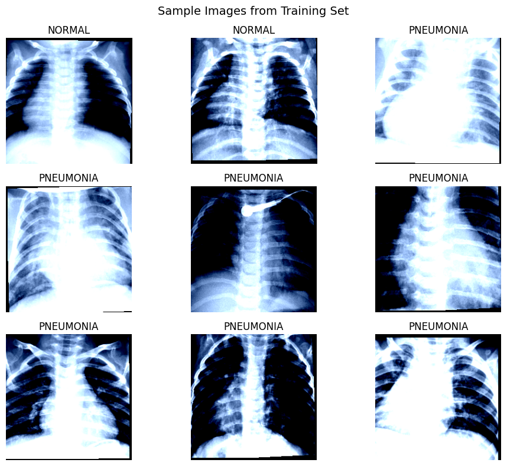

```python
import matplotlib.pyplot as plt

def show_batch(dl, class_names):
    images, labels = next(iter(dl))          # images: [B, C, H, W]
    fig, axes = plt.subplots(3, 3, figsize=(10, 8))

    for i, ax in enumerate(axes.flat):
        img = images[i]

        if img.shape[0] == 1:
            # 1-channel: (1,H,W) -> (H,W)
            img = img.squeeze(0)
            ax.imshow(img, cmap='gray')
        else:
            # 3-channel: (3,H,W) -> (H,W,3)
            img = img.permute(1, 2, 0)
            ax.imshow(img)

        ax.set_title(class_names[labels[i].item()])
        ax.axis('off')

    plt.suptitle("Sample Images from Training Set", fontsize=14)
    plt.tight_layout()
    plt.show()

show_batch(train_loader, full_train_dataset.classes)
```

## **Class Distribution**

The bar chart below shows the class distribution in the training subset. As expected, pneumonia cases substantially outnumber normal ones — a class imbalance that is addressed during training through a weighted loss function.

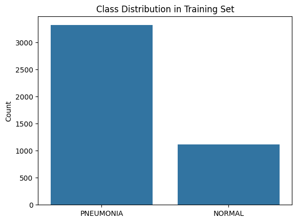

```python
from collections import Counter
import seaborn as sns
import matplotlib.pyplot as plt

# labels from the *subset* (this is fine)
labels = [label for _, label in train_dataset]
label_counts = Counter(labels)


sns.barplot(
    x=[class_names[i] for i in label_counts.keys()],
    y=list(label_counts.values())
)
plt.title("Class Distribution in Training Set")
plt.ylabel("Count")
plt.show()
```

## **Model Architecture**

The backbone used in this project is **EfficientNet-B0**, pretrained on ImageNet.  
Since EfficientNet expects three-channel inputs, the preprocessing pipeline was designed to convert grayscale X-rays to RGB — avoiding any need to modify the model's convolutional layers and preserving the pretrained feature extractor intact.  
The only architectural change applied was replacing the final classification head with a two-unit linear layer, mapping the learned features to the two target classes: **NORMAL** and **PNEUMONIA**.

```python
import torch
import torch.nn as nn
from torchvision import models


device = torch.device('cuda' if torch.cuda.is_available() else 'cpu')

model = models.efficientnet_b0(weights=models.EfficientNet_B0_Weights.IMAGENET1K_V1)
in_features = model.classifier[1].in_features
model.classifier[1] = nn.Linear(in_features, 2)

model = model.to(device)
```

```
Downloading: "https://download.pytorch.org/models/efficientnet_b0_rwightman-7f5810bc.pth" to /root/.cache/torch/hub/checkpoints/efficientnet_b0_rwightman-7f5810bc.pth
```

## **Training Configuration**

Several refinements were introduced to the training procedure to better suit the dataset characteristics and the EfficientNet architecture:

- **Class-weighted loss:** Class weights were computed from the training label distribution and passed to `nn.CrossEntropyLoss`, ensuring that the minority class (NORMAL) contributes proportionally stronger gradients during training and preventing the model from defaulting to predicting the majority class.
- **Layer-specific learning rates:** The Adam optimizer was configured with a lower learning rate for the pretrained EfficientNet backbone (`1e-4`) and a higher rate for the newly initialized classifier head (`3e-4`), allowing conservative fine-tuning of learned features while enabling faster adaptation of the final layer.
- **Learning rate scheduling:** A `ReduceLROnPlateau` scheduler was applied to automatically reduce the learning rate when validation loss stopped improving, helping the model converge more smoothly in later epochs.
- **Early stopping on validation loss:** Training was halted when validation loss showed no meaningful improvement for 10 consecutive epochs. Monitoring loss rather than accuracy — as done in the baseline — provides a more sensitive and stable signal for detecting overfitting.

```python
import numpy as np
import torch
from sklearn.utils.class_weight import compute_class_weight

all_labels = []

# Collect labels from DataLoader
for _, labels in train_loader:
    all_labels.extend(labels.cpu().numpy())

# Convert to NumPy array
y = np.array(all_labels)

# Compute class weights
weights = compute_class_weight(class_weight='balanced', classes=np.unique(y), y=y)

# Convert to tensor for PyTorch loss
class_weights = torch.tensor(weights, dtype=torch.float32).to(device)

print("Class weights:", class_weights)
```

```
Class weights: tensor([1.9866, 0.6682], device='cuda:0')
```

```python
import torch
import torch.nn as nn
import torch.optim as optim
from torch.optim.lr_scheduler import ReduceLROnPlateau
import copy

# Configuration
EPOCHS = 50
PATIENCE = 10  # for early stopping
BEST_MODEL_PATH = "best_model.pth"

# Loss, Optimizer, Scheduler
criterion = nn.CrossEntropyLoss(weight=class_weights)
optimizer = optim.Adam([
    {'params': model.features.parameters(), 'lr': 1e-4},      # backbone
    {'params': model.classifier.parameters(), 'lr': 3e-4}     # classifier head
])

scheduler = ReduceLROnPlateau(
    optimizer,
    mode='min',        # we want to MINIMIZE val_loss
    factor=0.3,
    patience=5,
    min_lr=1e-6
)

# Logging
train_losses, val_losses = [], []
train_accuracies, val_accuracies = [], []

# Early Stopping
best_val_loss = float("inf")
epochs_no_improve = 0
best_model_wts = copy.deepcopy(model.state_dict())

for epoch in range(EPOCHS):
    model.train()
    train_loss, correct, total = 0.0, 0, 0
    for images, labels in train_loader:
        images, labels = images.to(device), labels.to(device)

        optimizer.zero_grad()
        outputs = model(images)
        loss = criterion(outputs, labels)
        loss.backward()
        optimizer.step()

        train_loss += loss.item() * images.size(0)
        _, predicted = outputs.max(1)
        total += labels.size(0)
        correct += predicted.eq(labels).sum().item()

    train_loss /= total
    train_acc = correct / total

    train_losses.append(train_loss)
    train_accuracies.append(train_acc)

    # ---- validation ----
    model.eval()
    val_loss, correct, total = 0.0, 0, 0
    with torch.no_grad():
        for images, labels in val_loader:
            images, labels = images.to(device), labels.to(device)
            outputs = model(images)
            loss = criterion(outputs, labels)
            val_loss += loss.item() * images.size(0)
            _, predicted = outputs.max(1)
            total += labels.size(0)
            correct += predicted.eq(labels).sum().item()

    val_loss /= total
    val_acc = correct / total


    val_losses.append(val_loss)
    val_accuracies.append(val_acc)

    # ---- scheduler on LOSS -> mode='min' (see next section) ----
    scheduler.step(val_loss)

    print(f"Epoch {epoch+1}/{EPOCHS}  "
          f"Train Loss: {train_loss:.4f}, Acc: {train_acc:.4f}  "
          f"Val Loss: {val_loss:.4f}, Acc: {val_acc:.4f}")

    # ---- real early stopping on LOSS ----
    if val_loss < best_val_loss - 1e-4:     # small tolerance
        best_val_loss = val_loss
        best_model_wts = copy.deepcopy(model.state_dict())
        torch.save(best_model_wts, BEST_MODEL_PATH)
        print("📌 Best model saved.")
        epochs_no_improve = 0
    else:
        epochs_no_improve += 1
        print(f"No improvement for {epochs_no_improve} epoch(s).")

    if epochs_no_improve >= PATIENCE:
        print("⏹️ Early stopping triggered.")
        break

model.load_state_dict(best_model_wts)
print("✅ Training complete. Best model loaded.")
```

```
📌 Best model saved.
No improvement for 1 epoch(s).
📌 Best model saved.
📌 Best model saved.
No improvement for 1 epoch(s).
No improvement for 2 epoch(s).
📌 Best model saved.
No improvement for 1 epoch(s).
No improvement for 2 epoch(s).
📌 Best model saved.
No improvement for 1 epoch(s).
📌 Best model saved.
No improvement for 1 epoch(s).
No improvement for 2 epoch(s).
No improvement for 3 epoch(s).
No improvement for 4 epoch(s).
No improvement for 5 epoch(s).
No improvement for 6 epoch(s).
No improvement for 7 epoch(s).
No improvement for 8 epoch(s).
No improvement for 9 epoch(s).
No improvement for 10 epoch(s).
⏹️ Early stopping triggered.
✅ Training complete. Best model loaded.
```

## **Learning Curves**

The plots below show training and validation loss and accuracy across 22 epochs, after which early stopping was triggered.  
Training loss decreases steadily and consistently throughout, while validation loss converges rapidly in the first few epochs and then plateaus with slight oscillations — a typical pattern when fine-tuning a pretrained model on a relatively small dataset. The growing gap between training and validation loss in later epochs suggests mild overfitting, which the early stopping mechanism was designed to contain.  
On the accuracy side, both curves remain high throughout training, with train accuracy climbing steadily toward ~99% while validation accuracy fluctuates between approximately 97.5% and 99% — indicating that despite the loss gap, the model's predictive performance on unseen data remains strong and stable.

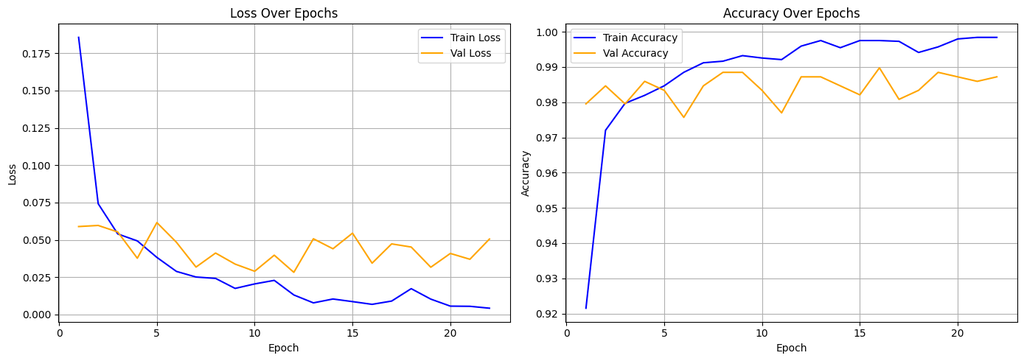

```python
import matplotlib.pyplot as plt

epochs_range = range(1, len(train_losses) + 1)

plt.figure(figsize=(14, 5))

# 📉 Loss Plot
plt.subplot(1, 2, 1)
plt.plot(epochs_range, train_losses, label='Train Loss', color='blue')
plt.plot(epochs_range, val_losses, label='Val Loss', color='orange')
plt.title("Loss Over Epochs")
plt.xlabel("Epoch")
plt.ylabel("Loss")
plt.legend()
plt.grid(True)

# 📈 Accuracy Plot
plt.subplot(1, 2, 2)
plt.plot(epochs_range, train_accuracies, label='Train Accuracy', color='blue')
plt.plot(epochs_range, val_accuracies, label='Val Accuracy', color='orange')
plt.title("Accuracy Over Epochs")
plt.xlabel("Epoch")
plt.ylabel("Accuracy")
plt.legend()
plt.grid(True)

plt.tight_layout()
plt.show()
```

## **Test Set Evaluation**

The model was evaluated on the held-out test set of 624 images, achieving an accuracy of 88% and a weighted F1-score of 0.87 — results comparable to the ResNet-18 baseline.  
The most clinically relevant metric is pneumonia recall, which reached 0.99, meaning only 2 out of 390 pneumonia cases were missed. This marginally improves upon the baseline's recall of 0.98, and is the most important outcome in a screening context where false negatives carry the highest clinical risk.  
The trade-off is a lower NORMAL recall of 0.69, meaning 73 healthy cases were incorrectly flagged as pneumonia. Though false positives in this setting lead to further clinical review rather than missed treatment — a more acceptable error in a screening scenario.  
Overall, the EfficientNet-B0 pipeline matches the baseline in aggregate performance while achieving marginally higher sensitivity for pneumonia detection. The primary added value of this work lies in the Grad-CAM interpretability component and the improved training configuration, rather than a gain in raw classification metrics.

```
              precision    recall  f1-score   support

      NORMAL       0.99      0.69      0.81       234
   PNEUMONIA       0.84      0.99      0.91       390

    accuracy                           0.88       624
   macro avg       0.91      0.84      0.86       624
weighted avg       0.90      0.88      0.87       624
```

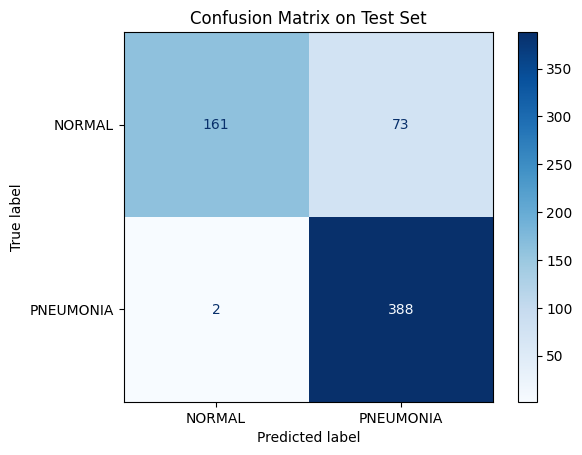

```python
from sklearn.metrics import classification_report, confusion_matrix, ConfusionMatrixDisplay
import matplotlib.pyplot as plt

# Put model in evaluation mode
model.eval()

# Collect predictions and ground truths
y_true = []
y_pred = []

with torch.no_grad():
    for images, labels in test_loader:
        images, labels = images.to(device), labels.to(device)
        outputs = model(images)
        _, predicted = torch.max(outputs, 1)
        y_true.extend(labels.cpu().numpy())
        y_pred.extend(predicted.cpu().numpy())

# Generate and print classification report
class_names = ['NORMAL', 'PNEUMONIA']
print(classification_report(y_true, y_pred, target_names=class_names))

# Plot confusion matrix
cm = confusion_matrix(y_true, y_pred)
disp = ConfusionMatrixDisplay(confusion_matrix=cm, display_labels=class_names)
disp.plot(cmap='Blues', values_format='d')
plt.title("Confusion Matrix on Test Set")
plt.show()
```

## **Interpretability with Grad-CAM++**

Deep learning models for medical imaging often behave as black boxes — they produce a prediction but provide no explanation for it. In a clinical setting, this is a significant limitation: a model that achieves high accuracy by focusing on irrelevant image regions (such as borders, annotations, or medical devices) cannot be trusted, regardless of its test performance.  
To address this, **Grad-CAM++ (Gradient-weighted Class Activation Mapping)** was applied as a post-hoc interpretability method. It produces a heatmap highlighting the image regions most influential to the model's decision. Warmer colors (red, yellow) indicate regions the model focused on; cooler colors (blue) indicate regions it largely ignored. Grad-CAM++ is an improved variant of the original Grad-CAM, offering more precise localization, particularly when multiple instances of a pattern are present in the same image.  
Two groups are visualized: correctly identified pneumonia cases (True Positives), to confirm the model attends to relevant lung regions, and missed pneumonia cases (False Negatives), to understand where the model's attention fails when it makes errors.

```python
import numpy as np
import torch
import torch.nn.functional as F
import matplotlib.pyplot as plt
```

```python
# ImageNet unnormalization
imagenet_mean = np.array([0.485, 0.456, 0.406])
imagenet_std  = np.array([0.229, 0.224, 0.225])

def unnormalize_img(img_tensor):
    img_np = img_tensor.permute(1, 2, 0).cpu().numpy()
    img_np = img_np * imagenet_std + imagenet_mean
    return np.clip(img_np, 0.0, 1.0)
```

```python
# Grad-CAM++
class GradCAMPlusPlus:
    def __init__(self, model, target_layer):
        self.model = model
        self.activations = None
        self.handle = target_layer.register_forward_hook(
            lambda m, i, o: setattr(self, 'activations', o)
        )

    def remove_hook(self):
        self.handle.remove()

    def generate(self, input_tensor, class_idx=None):
        self.model.eval()
        self.model.zero_grad()

        output = self.model(input_tensor)
        if class_idx is None:
            class_idx = output.argmax(dim=1).item()

        score = output[:, class_idx]
        activations = self.activations

        grads  = torch.autograd.grad(score, activations,
                                     retain_graph=True, create_graph=True)[0]
        grads2 = grads * grads
        grads3 = grads2 * grads

        sum_acts = activations.sum(dim=(2, 3), keepdim=True)
        eps      = 1e-8
        a_den    = 2 * grads2 + sum_acts * grads3
        a_den    = torch.where(a_den != 0, a_den, torch.ones_like(a_den) * eps)
        alphas   = grads2 / (a_den + eps)

        weights = (alphas * F.relu(grads)).sum(dim=(2, 3), keepdim=True)
        cam     = F.relu((weights * activations).sum(dim=1, keepdim=True))

        cam = cam[0, 0]
        cam = (cam - cam.min()) / (cam.max() + eps)
        return cam.detach().cpu().numpy()
```

```python
# Collect predictions
model.eval()
y_true, y_pred = [], []

with torch.no_grad():
    for images, labels in test_loader:
        images = images.to(device)
        preds  = model(images).argmax(dim=1).cpu().numpy()
        y_pred.extend(preds)
        y_true.extend(labels.numpy())

y_true = np.array(y_true)
y_pred = np.array(y_pred)

NORMAL, PNEUMONIA = 0, 1
TP = np.where((y_true == PNEUMONIA) & (y_pred == PNEUMONIA))[0]
FN = np.where((y_true == PNEUMONIA) & (y_pred == NORMAL))[0]

print(f"True Pneumonia (TP): {len(TP)}  |  False Negative (FN): {len(FN)}")
```

```
True Pneumonia (TP): 388  |  False Negative (FN): 2
```

```python
# Initialize Grad-CAM++
gradcampp = GradCAMPlusPlus(model, model.features[-1])
```

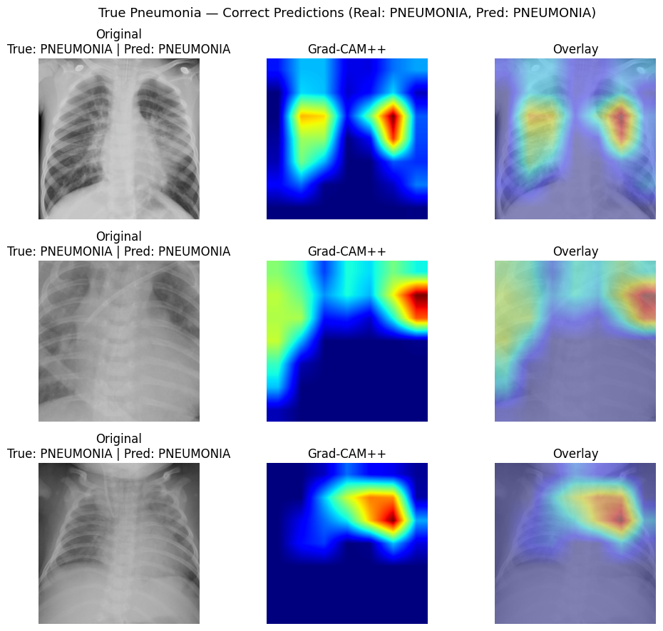

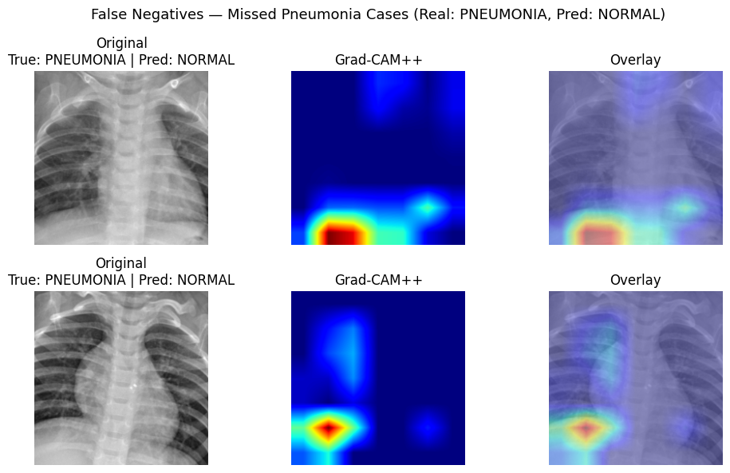

```python
# Visualization

def show_gradcampp(indices, title, n=3):
    if len(indices) == 0:
        print(f"No samples for: {title}")
        return

    indices = np.array(indices)
    chosen  = np.random.choice(indices, size=min(n, len(indices)), replace=False)

    fig, axes = plt.subplots(len(chosen), 3, figsize=(10, 3 * len(chosen)))
    if len(chosen) == 1:
        axes = np.expand_dims(axes, axis=0)

    for row, idx in enumerate(chosen):
        img_tensor, label = test_dataset[idx]
        input_tensor = img_tensor.unsqueeze(0).to(device)
        input_tensor.requires_grad_(True)

        with torch.no_grad():
            pred_idx = model(input_tensor).argmax(dim=1).item()

        cam    = gradcampp.generate(input_tensor)
        cam_up = F.interpolate(
            torch.from_numpy(cam).unsqueeze(0).unsqueeze(0),
            size=img_tensor.shape[1:],
            mode="bilinear",
            align_corners=False
        ).squeeze().cpu().numpy()

        img_np    = unnormalize_img(img_tensor)
        true_name = class_names[label]
        pred_name = class_names[pred_idx]

        axes[row, 0].imshow(img_np)
        axes[row, 0].set_title(f"Original\nTrue: {true_name} | Pred: {pred_name}")
        axes[row, 0].axis("off")

        axes[row, 1].imshow(cam_up, cmap="jet")
        axes[row, 1].set_title("Grad-CAM++")
        axes[row, 1].axis("off")

        axes[row, 2].imshow(img_np, alpha=0.6)
        axes[row, 2].imshow(cam_up, cmap="jet", alpha=0.4)
        axes[row, 2].set_title("Overlay")
        axes[row, 2].axis("off")

    plt.suptitle(title, fontsize=13)
    plt.tight_layout()
    plt.show()

# Show the two most informative groups
show_gradcampp(TP, "True Pneumonia — Correct Predictions (Real: PNEUMONIA, Pred: PNEUMONIA)")
show_gradcampp(FN, "False Negatives — Missed Pneumonia Cases (Real: PNEUMONIA, Pred: NORMAL)")

# Clean up hooks
gradcampp.remove_hook()
```

In correctly classified pneumonia cases, Grad-CAM++ consistently highlights regions within the lung fields suggesting that the model's predictions are driven by anatomically relevant features rather than image artifacts. This is an encouraging sign of clinically meaningful learned representations, though formal validation by a radiologist would be needed to draw stronger conclusions.